# Computational models related to Automatic Responses to Acoustically Rough Intervals

# 1 Release Notes

*Created: 1/2/2021*.

These files contains the computational models for “Automatic Responses to Acoustically Rough Intervals,” particularly the models of roughness and harmonicity. See also the behavioural data and the analyses at a [separate repository](https://tuomaseerola.github.io/primingroughnessdata/). The data is also available at OSF: https://osf.io/zmjpd/.

The paper is:

> Armitage, J., Lahdelma, I., & Eerola, T. (2021). Automatic responses to musical intervals: Contrasts in acoustic roughness predict affective priming in Western listeners. *Journal of Acoustical Society of America, 150(551)*. https://doi.org/10.1121/10.0005623

# 2 Harmonicity

Harmonicity for three common models: Harrison and Pearce (2018), Parncutt (1988) and Milne (2013), including the ranks of the model means and the model correlations.

```r
# Harmonicity 3 models: Harrison & Pearce 2018, Parncutt 1988, Milne 2013
source('model_harmonicity_data.R')
```

Model output (normalised to 1-10)

[output not shown]

Correlations

|  | Parn88 | Milne13 | Har18 |
| --- | --- | --- | --- |
| Parn88 | 1.00 | 0.90 | 0.94 |
| Milne13 | 0.90 | 1.00 | 0.96 |
| Har18 | 0.94 | 0.96 | 1.00 |

# 3 Roughness

Roughness values for three common models: Hutchinson and Knopoff (1978), Vassilakis (2001), and Wang et al. (2013), including the ranks of the model means and the model correlations.

```r
# Roughness 3 models: Hutchinson 1978, Vassilakis 2001, Wang et al 2013
source('model_roughness_data.R')
```

Model output (normalised to 1-10)

| Interval | Hutc78 | Vass01 | Wang13 | RoughnessMean | RoughnessRank |
| --- | --- | --- | --- | --- | --- |
| m2 | 10.00 | 10.00 | 10.00 | 10.00 | 11 |
| M2 | 5.51 | 7.63 | 4.79 | 5.98 | 10 |
| m3 | 2.74 | 1.94 | 3.66 | 2.78 | 4 |
| M3 | 1.92 | 3.52 | 4.66 | 3.37 | 5 |
| P4 | 1.43 | 1.00 | 3.64 | 2.02 | 2 |
| TT | 2.44 | 2.64 | 2.70 | 2.60 | 3 |
| P5 | 1.00 | 3.50 | 1.00 | 1.83 | 1 |
| m6 | 2.37 | 4.93 | 4.75 | 4.01 | 7 |
| M6 | 1.66 | 4.51 | 5.98 | 4.05 | 8 |
| m7 | 2.54 | 5.03 | 5.70 | 4.42 | 9 |
| M7 | 4.94 | 2.90 | 2.58 | 3.47 | 6 |

Correlations

|  | Hutc78 | Vass01 | Wang13 |
| --- | --- | --- | --- |
| Hutc78 | 1.00 | 0.79 | 0.69 |
| Vass01 | 0.79 | 1.00 | 0.77 |
| Wang13 | 0.69 | 0.77 | 1.00 |

Model output for additional mistuned intervals

| Interval | Wang13 | Wang13_interpolated |
| --- | --- | --- |
| d2 (Detuned piano m2) | 1.36 | 14.44 |
| s2 (Detuned Shepard m2) | 1.07 | 10.11 |
| s5 (Shepard P5) | 0.06 | -5.56 |

# 4 Empirical dissonance ratings

Empirical ratings from classic studies by Huron (1994) and Bowling, Purves, and Gill (2018).

```r
# Empirical data from Huron 1994 and Bowling et al 2018
source('empirical_data.R')
```

Empirical ratings (normalised to 1-10)

| Interval | Malm18 | Hutch79 | Kame69 | Bowl18 | EmpiricalMean | EmpiricalRank |
| --- | --- | --- | --- | --- | --- | --- |
| m2 | 10.00 | 10.00 | 10.00 | 10.00 | 10.00 | 11 |
| M2 | 8.58 | 5.76 | 8.71 | 7.80 | 7.71 | 10 |
| m3 | 5.88 | 2.71 | 6.14 | 4.19 | 4.73 | 6 |
| M3 | 3.51 | 1.64 | 5.50 | 2.16 | 3.20 | 4 |
| P4 | 3.37 | 1.44 | 4.86 | 3.10 | 3.19 | 3 |
| TT | 6.35 | 2.37 | 7.43 | 7.31 | 5.87 | 8 |
| P5 | 1.00 | 1.00 | 1.00 | 1.00 | 1.00 | 1 |
| m6 | 4.17 | 2.20 | 6.79 | 5.10 | 4.56 | 5 |
| M6 | 2.42 | 1.49 | 2.93 | 4.10 | 2.74 | 2 |
| m7 | 6.87 | 2.50 | 5.50 | 8.16 | 5.76 | 7 |
| M7 | 8.58 | 5.03 | 6.14 | 8.16 | 6.98 | 9 |

Correlations

|  | Malm18 | Hutch79 | Kame69 |
| --- | --- | --- | --- |
| Malm18 | 1.00 | 0.86 | 0.86 |
| Hutch79 | 0.86 | 1.00 | 0.78 |
| Kame69 | 0.86 | 0.78 | 1.00 |

# 5 Create variable deltas for the interval pairs

```r
source('deltas.R')
```

| IntervalPairs | Harmonicity_Delta | Roughness_Delta | Empirical_Delta |
| --- | --- | --- | --- |
| m2P5 | 9.00 | 8.17 | 9.00 |
| m2tt | 0.10 | 7.40 | 4.13 |
| m3M3 | 3.30 | 0.59 | 1.53 |
| m6M6 | 3.30 | 0.04 | 1.83 |
| M7P5 | 9.00 | 1.64 | 5.98 |
| ttP5 | 8.90 | 0.76 | 4.87 |
| m2M3 | 4.07 | 6.63 | 6.80 |
| m2P5 | 5.32 | 4.15 | 6.71 |

| IntervalPairs | Harmonicity_Delta | Roughness_Delta | Empirical_Delta | Harm_D_Class | Rough_D_Class | Emp_D_Class |
| --- | --- | --- | --- | --- | --- | --- |
| m2P5 | 9.00 | 8.17 | 9.00 | High | High | High |
| m2tt | 0.10 | 7.40 | 4.13 | Low | High | Low |
| m3M3 | 3.30 | 0.59 | 1.53 | Low | Low | Low |
| m6M6 | 3.30 | 0.04 | 1.83 | Low | Low | Low |
| M7P5 | 9.00 | 1.64 | 5.98 | High | Low | High |
| ttP5 | 8.90 | 0.76 | 4.87 | High | Low | Low |
| m2M3 | 4.07 | 6.63 | 6.80 | Low | High | High |
| m2P5 | 5.32 | 4.15 | 6.71 | High | High | High |

[1] “Mistuned pairs”

Mistuned intervals

| IntervalPairs | Roughness_Delta |
| --- | --- |
| d2P5 | 12.61 |
| s2S5 | 15.67 |

# 6 Create graphs for selected stimuli

Take four intervals that together span low to high delta in roughness and plot the amplitude and spectra for each.

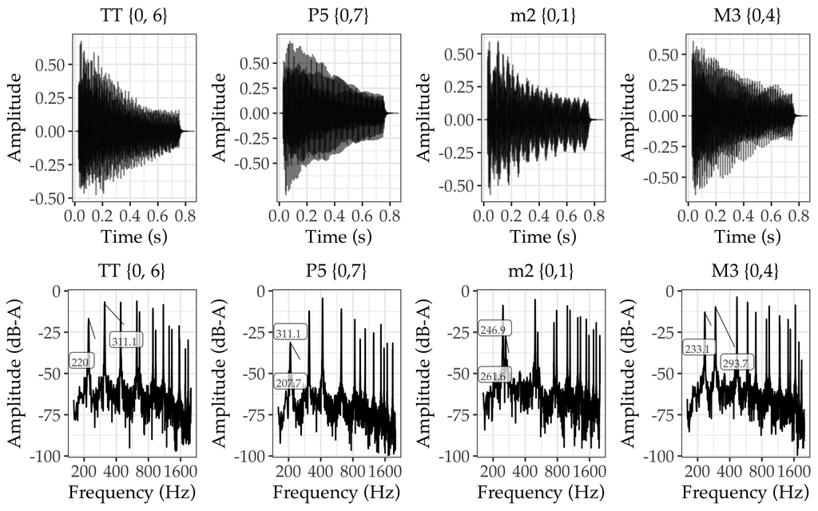

# 7 References

Bowling, Daniel L., Dale Purves, and Kamraan Z. Gill. 2018. “Vocal Similarity Predicts the Relative Attraction of Musical Chords.” *Proceedings of the National Academy of Sciences* 115 (1): 216–21.

Harrison, Peter, and Marcus Pearce. 2018. “An energy-based generative sequence model for testing sensory theories of Western harmony.” In *Proceedings of the 19th International Society for Music Information Retrieval Conference*, 160–67. Paris, France.

Huron, David. 1994. “Interval-Class Content in Equally Tempered Pitch-Class Sets: Common Scales Exhibit Optimum Tonal Consonance.” *Music Perception: An Interdisciplinary Journal* 11 (3): 289–305.

Hutchinson, William, and Leon Knopoff. 1978. “The acoustic component of Western consonance.” *Interface* 7 (1): 1–29.

Milne, Andrew J. 2013. “A Computational Model of the Cognition of Tonality.” PhD thesis, The Open University.

Parncutt, Richard. 1988. “Revision of Terhardt’s psychoacoustical model of the root(s) of a musical chord.” *Music Perception* 6 (1): 65–93.

Vassilakis, Panteleimon Nestor. 2001. “Perceptual and Physical Properties of Amplitude Fluctuation and Their Musical Significance.” PhD thesis, University of California, Los Angeles.

Wang, YS, GQ Shen, H Guo, XL Tang, and T Hamade. 2013. “Roughness Modelling Based on Human Auditory Perception for Sound Quality Evaluation of Vehicle Interior Noise.” *Journal of Sound and Vibration* 332 (16): 3893–3904.